# ESAME FONDAMENTI DI SCIENZA DEI DATI E LABORATORIO

Moreno Scozzi

# Osservazione sui dati riguardanti gli attacchi di cuore e le loro cause.

In seguito alla vicenda accaduta recentemente riguardo al giocatore della Danimarca Christian Eriksen, il quale è svenuto in campo al 43’ minuto di Danimarca-Finlandia, colto da un malore, è apparso subito in gravi condizioni, tanto da rendere necessario l’intervento dei sanitari con un massaggio cardiaco durato circa 10 minuti.

L’obiettivo di questo studio è quello di mostrare le cause degli attacchi di cuore e cercare di capire come prevenirli.

# Importiamo il DataSet

Come prima cosa importiamo il DataSet per analizzare i dati riguardanti età, il sesso, la pressione sanguigna a riposo (in mm Hg), il livello di colesterolo in mg/dl prelevato tramite sensore BMI, la glicemia a digiuno, i risultati elettrocardiografici a riposo, la frequenza cardiaca massima raggiunta, angina indotta dall’esercizio, Depressione ST (fa riferimento ad un’alterazione dell’elettrocardiogramma di superficie) indotta dall’esercizio rispetto al riposo.

# Grafico riguardante il sesso delle persone

Iniziamo con il distinguere i due sessi e analizzare quello più a rischio.

# Grafico riguardante il sesso delle persone

In questo grafico possiamo vedere che il genere maschile (68%) è più soggetto ad attacchi di cuore rispetto al genere femminile (32%).

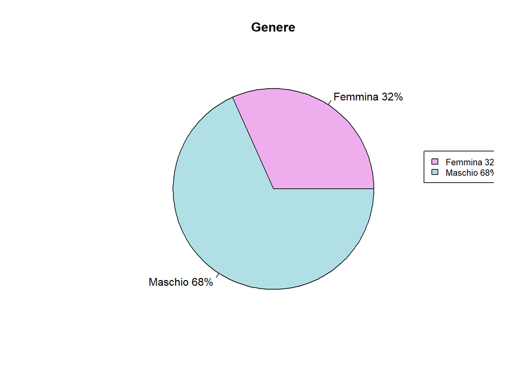

# Analisi sesso

Sebbene l’infarto sia una delle principali cause di morte sia per gli uomini che le donne, due pazienti su tre che vanno incontro a problemi cardiaci sono maschi, e in generale questo tipo di patologie colpisce gli uomini dai dieci ai quindici anni prima che le donne. Per molto tempo non si è mai riuscita a dare una spiegazione a ciò, fino a quando uno studio nel 2012 pubblica su The Lancet una relazione nella quale suggerisce che parte della risposta sia da cercare nel cromosoma Y, che definisce il sesso maschile.

# Riguardante il livello di colesterolo

Nel seguente grafico notiamo che il livello del colesterolo compreso tra i 200 e i 300 mg/dl sono a forte rischio di infarto, da ciò possiamo dedurre che bisogna fare attenzione alla percentuale di colesterolo in quanto influisce sulla salute del cuore.

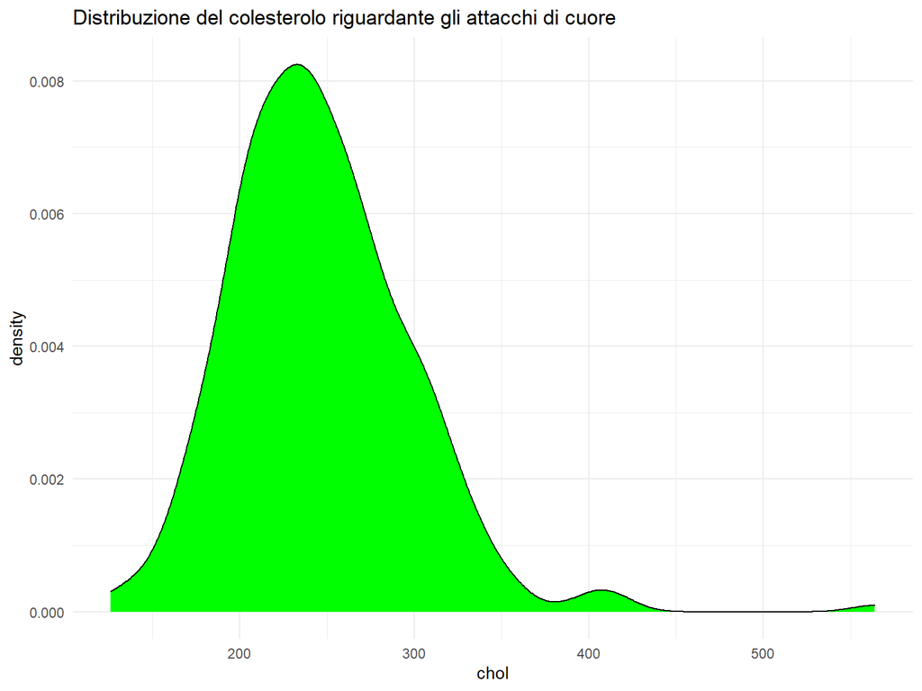

# Riguardante il livello di colesterolo

Ora guardiamolo con un altro grafico mettendo in relazione il livello di colesterolo e il numero degli attacchi di cuore in base al sesso.

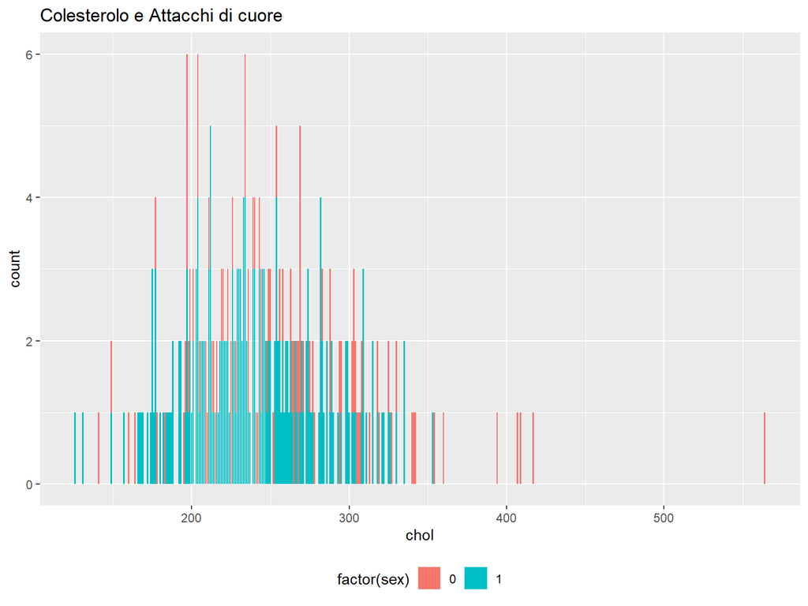

# Chest pain type

Con il prossimo grafico facciamo una distinzione dei diversi tipi di dolore toracico causato dal cuore.

# Angina

L’angina è dolore toracico o fastidio causato quando il muscolo cardiaco non riceve abbastanza sangue ricco di ossigeno. Inoltre, alcune persone non avvertono alcun dolore ma hanno altri sintomi come mancanza di respiro o affaticamento.

# Chest pain type

Possiamo notare che abbiamo un maggior numero di casi in cui le persone che hanno avuto attacchi di cuore erano asintomatiche (factor(cp) = 0), a seguire riscontriamo una maggioranza di casi riguardo attacchi dovuti ad un’angina atipica (factor(cp) = 2) rispetto ad un’angina tipica (factor(cp) = 1).Pochi sono i casi un cui non si tratta di angina (factor(cp) = 3).

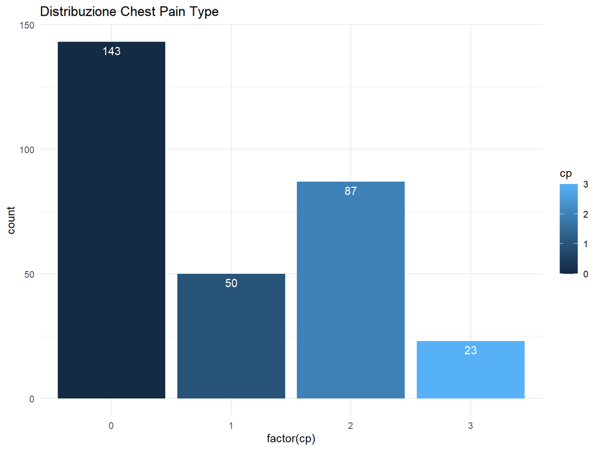

# Sintomi

Alcuni atleti presentano segnali d’allarme come svenimento o respiro affannoso. Spesso, tuttavia, gli atleti non riconoscono o non riferiscono tali sintomi e il primo segnale è che il soggetto smette improvvisamente di respirare e collassa. I sintomi possono essere:

- Dolore toracico
- Sudore
- Dispnea
- Nausea e vomitare
- Tosse o ansare

# Verifica idonetà atleta

Un importante aspetto dell’attività competitiva consiste nel verificare se l’atleta sia in grado di esercitare il proprio giudizio, la propria valutazione libera e indipendente per interrompere l’attività sportiva nel caso sia necessario.

È inoltre importante notare che, a causa delle circostanze particolari e delle pressioni dello sport competitivo in generale, spesso l’atleta non è in grado di interrompere l’attività fisica, anche quando si presentino obiettive necessità mediche di interromperla.

# Angina

Quindi una domanda sorge spontanea: “L’angina è in qualche modo collegata nello sport?”

# Angina

Guardando questo grafico possiamo dedurre di no, in quanto è presente una prevalenza di casi di angina che non sono dovuti ad esercizio fisico (1 = yes; 0 = no). Quindi possiamo concludere dicendo che l’esercizio fisico non induce a casi di angina.

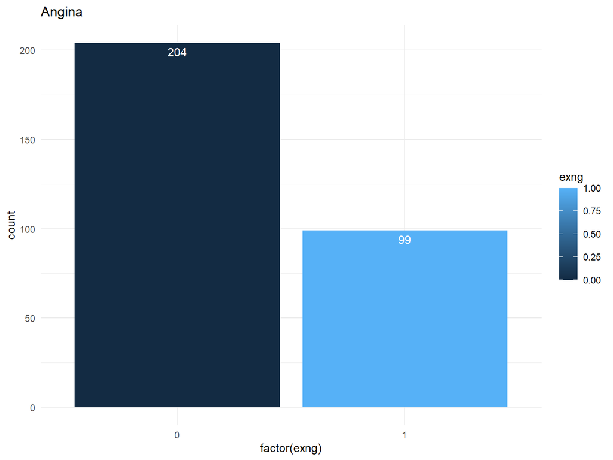

# Cause della morte caridaca improvvisa degli atleti

Generalmente, le cause di morte improvvisa durante l’attività fisica sono molto diverse per gli atleti giovani rispetto a quelli meno giovani. Tuttavia, in tutti gli atleti il decesso può essere provocato da asma, colpo di calore e uso di farmaci dopanti o droghe che causano improvvise alterazioni del ritmo cardiaco.

# Come prevenire attacchi di cuore?

I comportamenti che possono ridurre il rischio di infarto sono, nel dettaglio:

- alimentazione sana.
- astensione dal fumo.
- controllo del proprio peso forma.
- svolgimento di attività fisica non intensa, moderata

# Distribuzione heart/age/blood

Con questo grafico mettiamo in relazione l’età e la frequenza cardiaca massima raggiunta (thalach). Possiamo notare che ha una distribuzione discendente, con l’abbassarsi dell’età dell’individuo aumenta la frequenza cardiaca massima raggiunta, e viceversa.

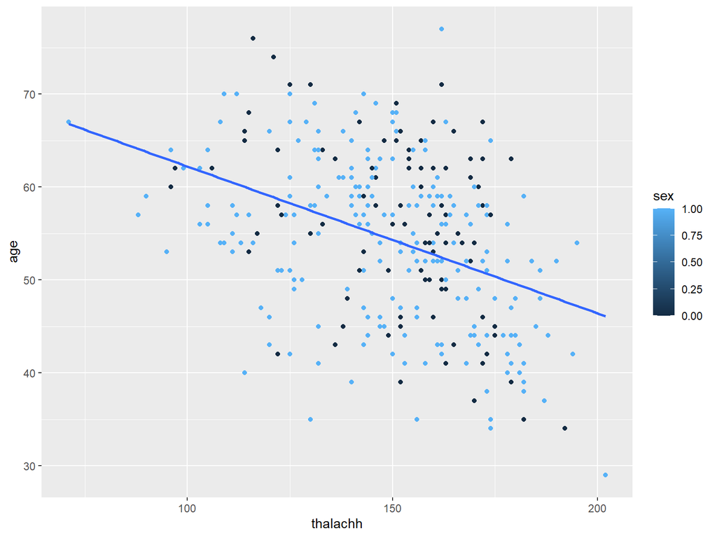

# Distribuzione 2

Con lo stesso tipo di grafico, mettiamo ora in relazione la pressione sanguigna a riposo (trestbps) e la frequenza cardiaca massima raggiunta (thalach). Notiamo che ha una distribuzione diversa dal grafico precedente, questa risulta omogenea e costante.

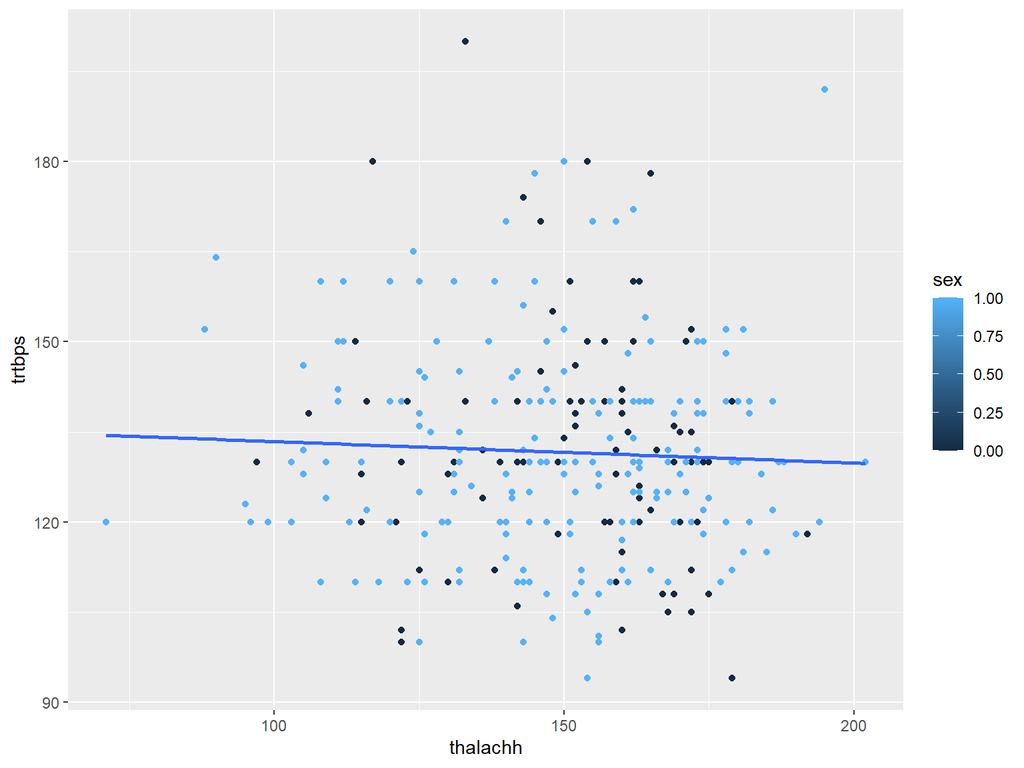

# Conclusioni

Quindi, gli attacchi di cuore possono essere prevenuti?

- Diciamo di si, possono essere prevenuti tramite controlli preriodici e la giusta alimentazione in relazione al colesterolo, che abbiamo visto essere molto incisivo.
- Purtroppo, però, non abbiamo la certezza di evitare queste situazioni, però con la giusta attenzione si possono salvare delle vite come, appunto, successo al giocatore.